# Project #7: Exploring Red Wines

Ishita Joshi

December 30, 2018

Built with R Studio 3.5.2 on Sun Dec 30 12:17:53 2018

========================================================

# Univariate Plots Section

```
## 'data.frame':    1599 obs. of  13 variables:
##  $ X                   : int  1 2 3 4 5 6 7 8 9 10 ...
##  $ fixed.acidity       : num  7.4 7.8 7.8 11.2 7.4 7.4 7.9 7.3 7.8 7.5 ...
##  $ volatile.acidity    : num  0.7 0.88 0.76 0.28 0.7 0.66 0.6 0.65 0.58 0.5 ...
##  $ citric.acid         : num  0 0 0.04 0.56 0 0 0.06 0 0.02 0.36 ...
##  $ residual.sugar      : num  1.9 2.6 2.3 1.9 1.9 1.8 1.6 1.2 2 6.1 ...
##  $ chlorides           : num  0.076 0.098 0.092 0.075 0.076 0.075 0.069 0.065 0.073 0.071 ...
##  $ free.sulfur.dioxide : num  11 25 15 17 11 13 15 15 9 17 ...
##  $ total.sulfur.dioxide: num  34 67 54 60 34 40 59 21 18 102 ...
##  $ density             : num  0.998 0.997 0.997 0.998 0.998 ...
##  $ pH                  : num  3.51 3.2 3.26 3.16 3.51 3.51 3.3 3.39 3.36 3.35 ...
##  $ sulphates           : num  0.56 0.68 0.65 0.58 0.56 0.56 0.46 0.47 0.57 0.8 ...
##  $ alcohol             : num  9.4 9.8 9.8 9.8 9.4 9.4 9.4 10 9.5 10.5 ...
##  $ quality             : int  5 5 5 6 5 5 5 7 7 5 ...
```

The dataset has 1599 ovservations of 13 variables, and varicable X can be simply seen as index, so I’d like to remove this column.

Now, I have 12 variables. Since the most important part is quality, it would be necessary to see the basic statistics on it.

```
##  fixed.acidity   volatile.acidity  citric.acid    residual.sugar
##  Min.   : 4.60   Min.   :0.1200   Min.   :0.000   Min.   : 0.900
##  1st Qu.: 7.10   1st Qu.:0.3900   1st Qu.:0.090   1st Qu.: 1.900
##  Median : 7.90   Median :0.5200   Median :0.260   Median : 2.200
##  Mean   : 8.32   Mean   :0.5278   Mean   :0.271   Mean   : 2.539
##  3rd Qu.: 9.20   3rd Qu.:0.6400   3rd Qu.:0.420   3rd Qu.: 2.600
##  Max.   :15.90   Max.   :1.5800   Max.   :1.000   Max.   :15.500
##    chlorides       free.sulfur.dioxide total.sulfur.dioxide
##  Min.   :0.01200   Min.   : 1.00       Min.   :  6.00
##  1st Qu.:0.07000   1st Qu.: 7.00       1st Qu.: 22.00
##  Median :0.07900   Median :14.00       Median : 38.00
##  Mean   :0.08747   Mean   :15.87       Mean   : 46.47
##  3rd Qu.:0.09000   3rd Qu.:21.00       3rd Qu.: 62.00
##  Max.   :0.61100   Max.   :72.00       Max.   :289.00
##     density             pH          sulphates         alcohol
##  Min.   :0.9901   Min.   :2.740   Min.   :0.3300   Min.   : 8.40
##  1st Qu.:0.9956   1st Qu.:3.210   1st Qu.:0.5500   1st Qu.: 9.50
##  Median :0.9968   Median :3.310   Median :0.6200   Median :10.20
##  Mean   :0.9967   Mean   :3.311   Mean   :0.6581   Mean   :10.42
##  3rd Qu.:0.9978   3rd Qu.:3.400   3rd Qu.:0.7300   3rd Qu.:11.10
##  Max.   :1.0037   Max.   :4.010   Max.   :2.0000   Max.   :14.90
##     quality
##  Min.   :3.000
##  1st Qu.:5.000
##  Median :6.000
##  Mean   :5.636
##  3rd Qu.:6.000
##  Max.   :8.000
```

rwine$quality <- as.factor(rwine$quality) levels(rwine$quality)

summary(rwine)

Most red wines have quality “5” or “6”. Most red wines have a pH between “3.210” and “3.400”. Most red wines have chlorides between “0.07” and “0.09”.

At first, I will plot simple historams of all variables to see how they distribute.

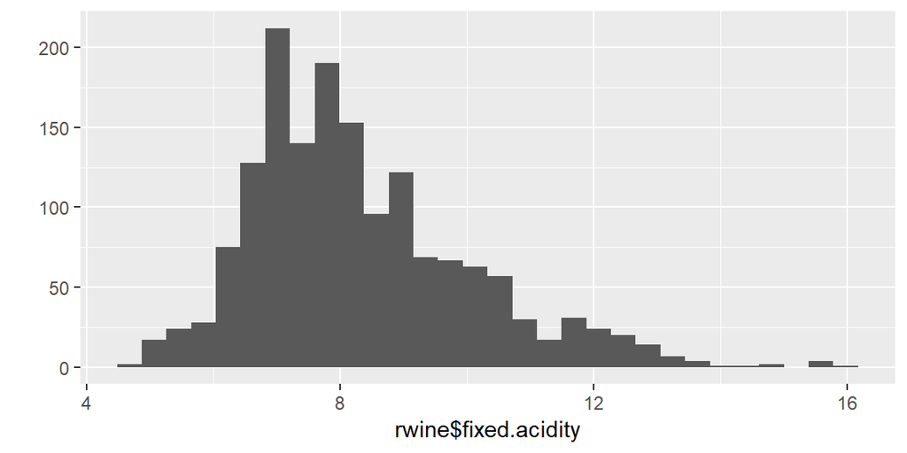

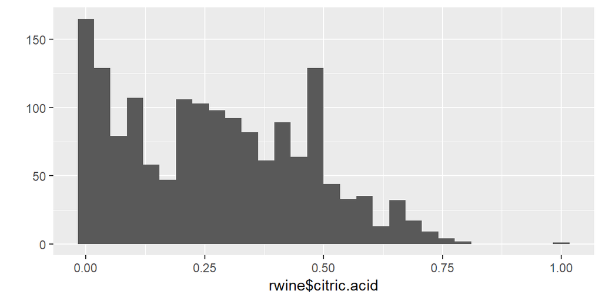

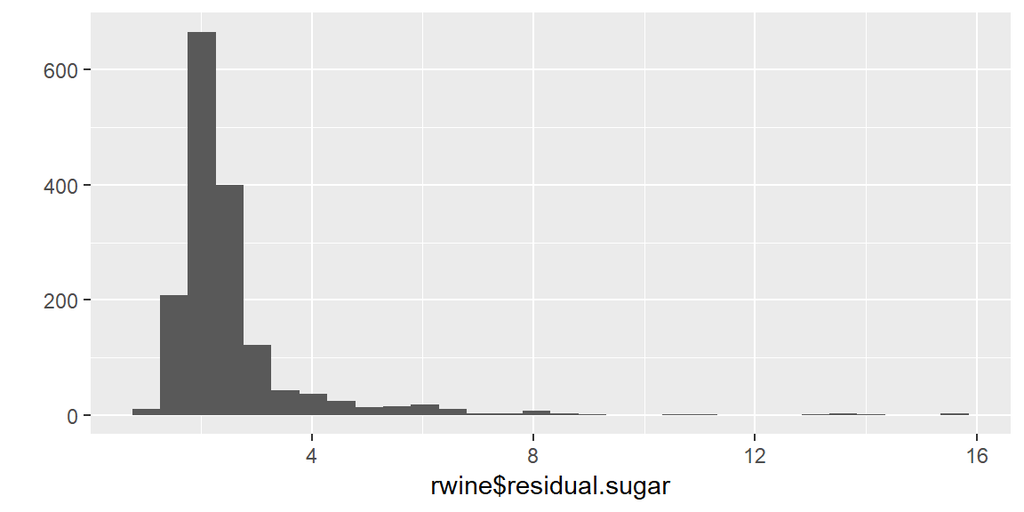

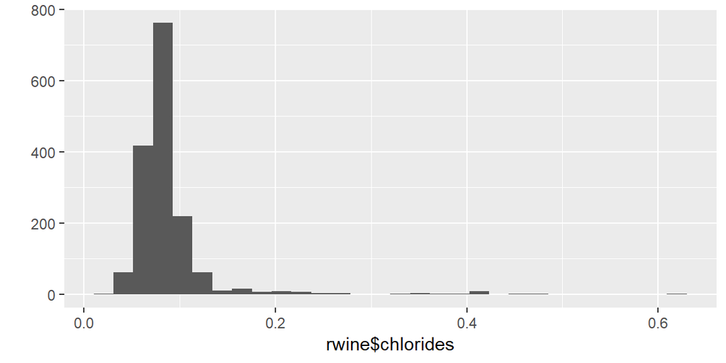

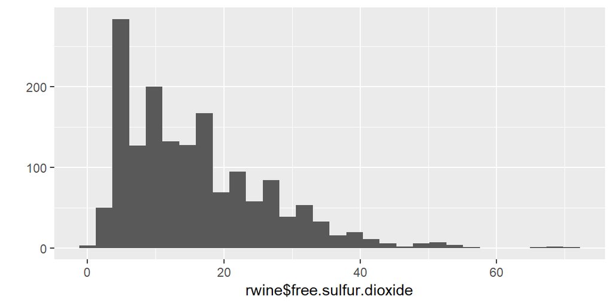

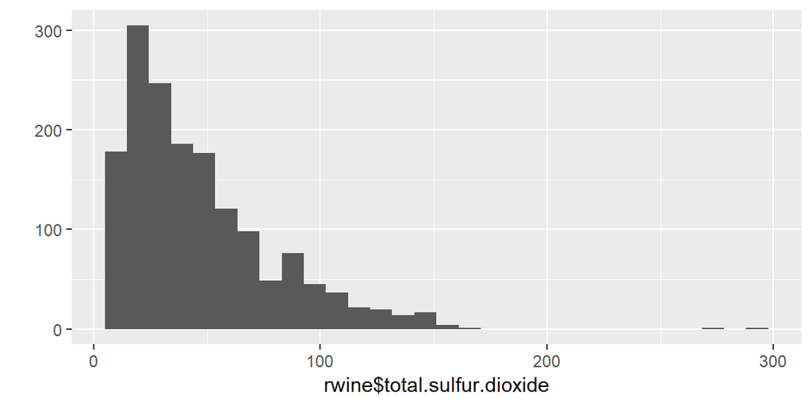

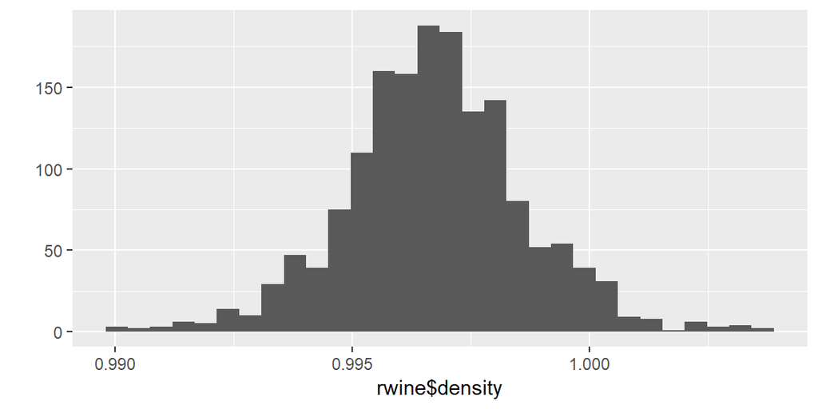

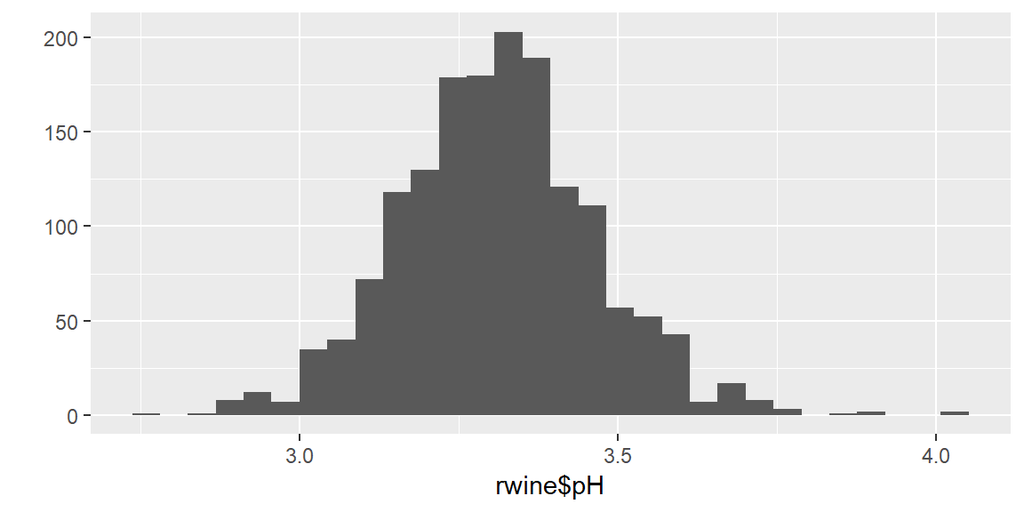

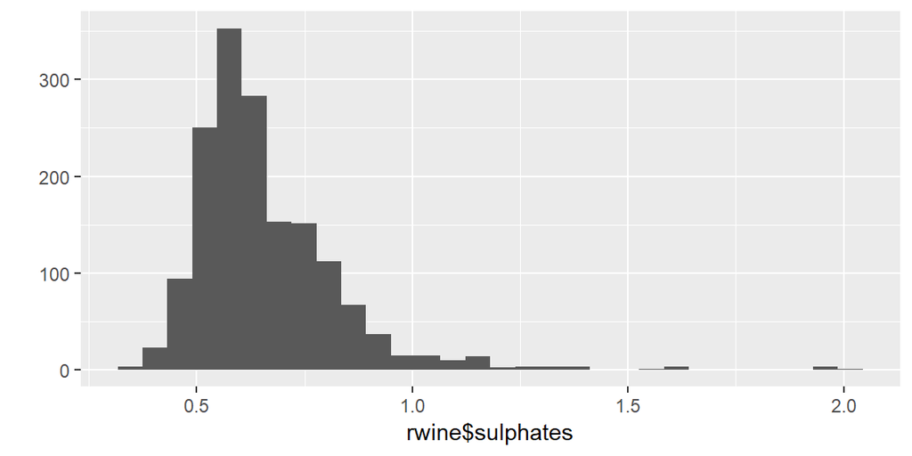

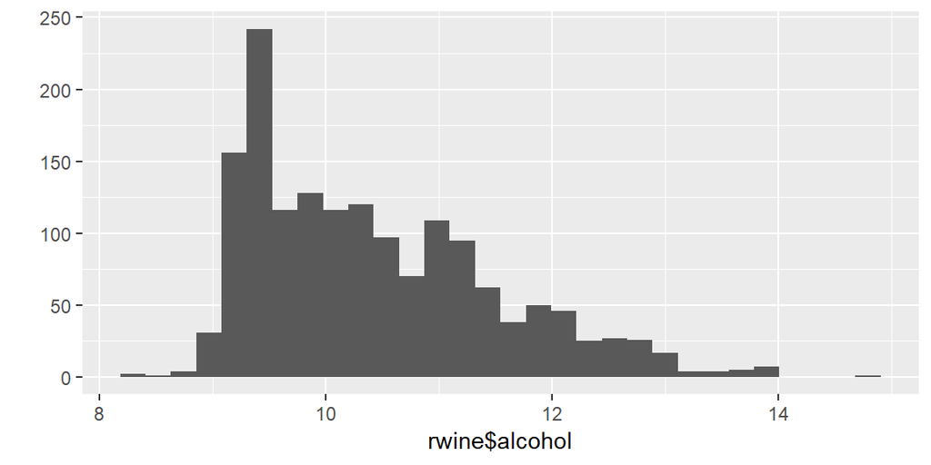

```
##    Min. 1st Qu.  Median    Mean 3rd Qu.    Max.
##   3.000   5.000   6.000   5.636   6.000   8.000
```

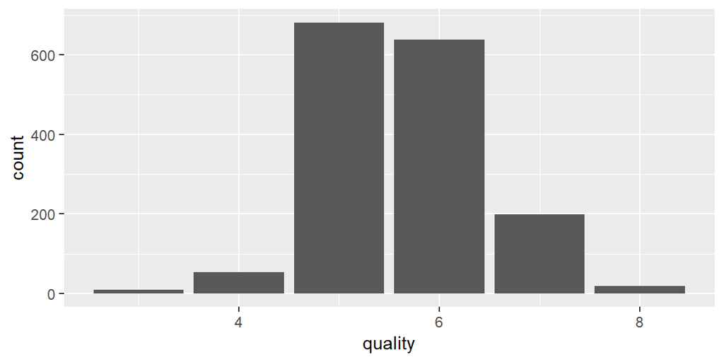

```
##     bad average    good
##      63    1518      18
```

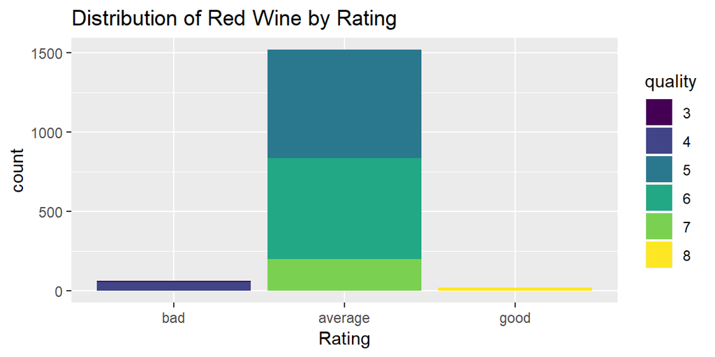

Most wine are in average rating

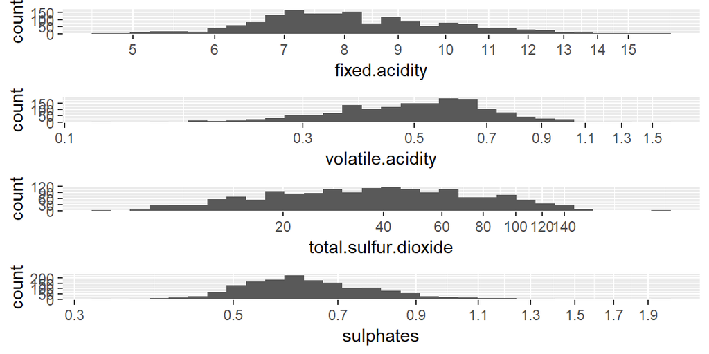

On log10 scale, fixed.acidity, volatile.acidity, total.sulfur.dioxide, and sulphates appear to be normal distributed, although they are still with some outliers.

## Volatile acidity

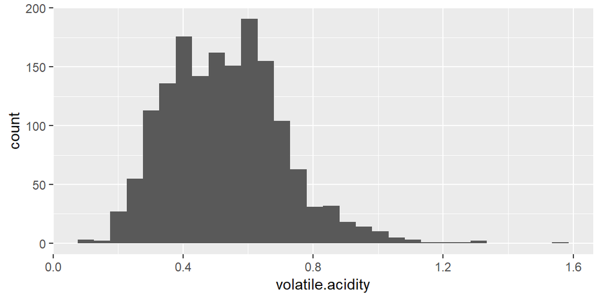

```
##    Min. 1st Qu.  Median    Mean 3rd Qu.    Max.
##  0.1200  0.3900  0.5200  0.5278  0.6400  1.5800
```

```
##
## FALSE  TRUE
##  1595     4
```

Most wines have volatile.acidity between 0.39 and 0.64,there are several outliers.

## Citric acid

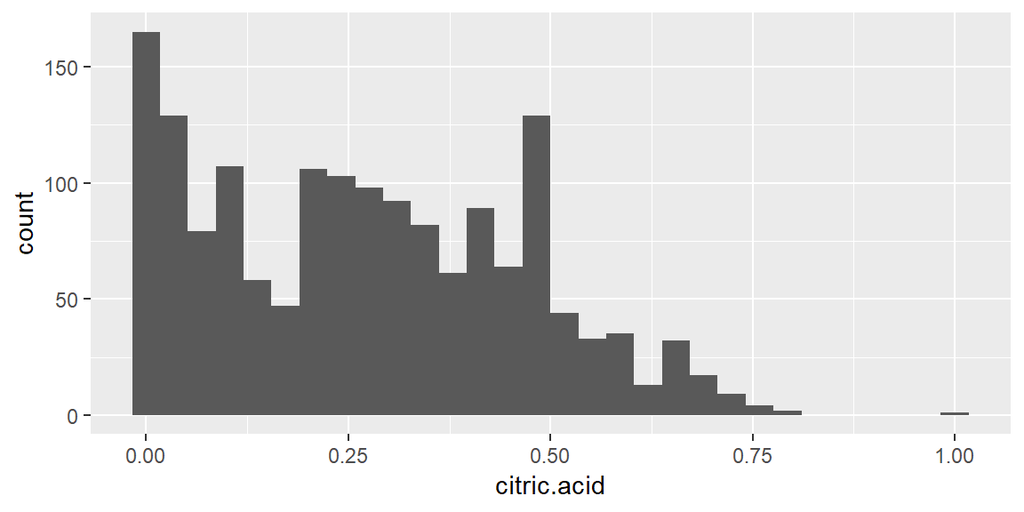

```
##    Min. 1st Qu.  Median    Mean 3rd Qu.    Max.
##   0.000   0.090   0.260   0.271   0.420   1.000
```

```
##
## FALSE  TRUE
##  1467   132
```

Some wines don’t have citric.acid.

## Chloride

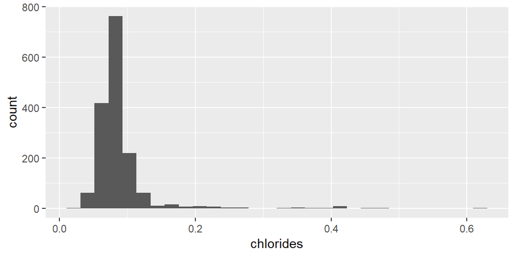

Now Let’s see a histogram without first and last 5% quantile

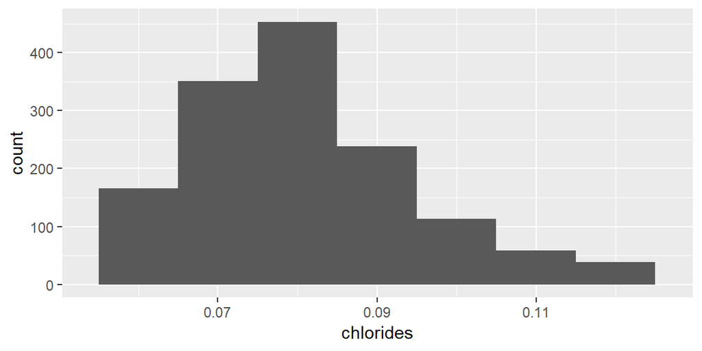

Do the chlorides influence the quanlity of red wines?

```
##    Min. 1st Qu.  Median    Mean 3rd Qu.    Max.
## 0.01200 0.07000 0.07900 0.08747 0.09000 0.61100
```

```
##
## FALSE  TRUE
##  1595     4
```

## Sulphates

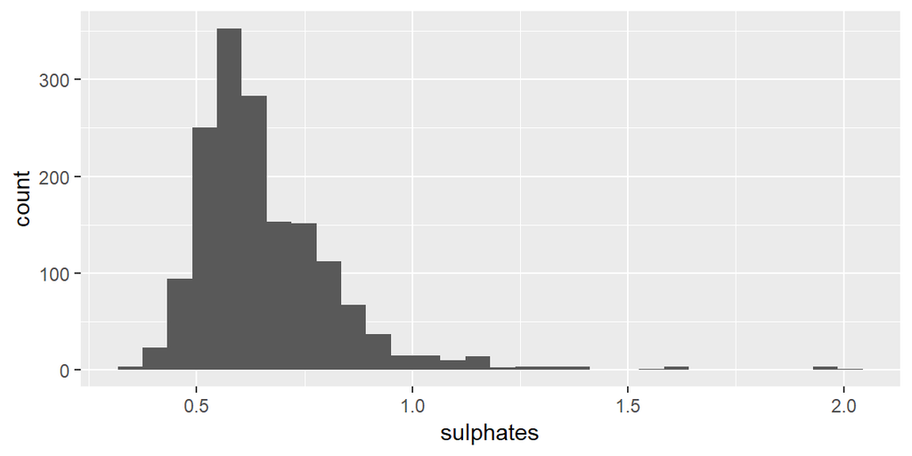

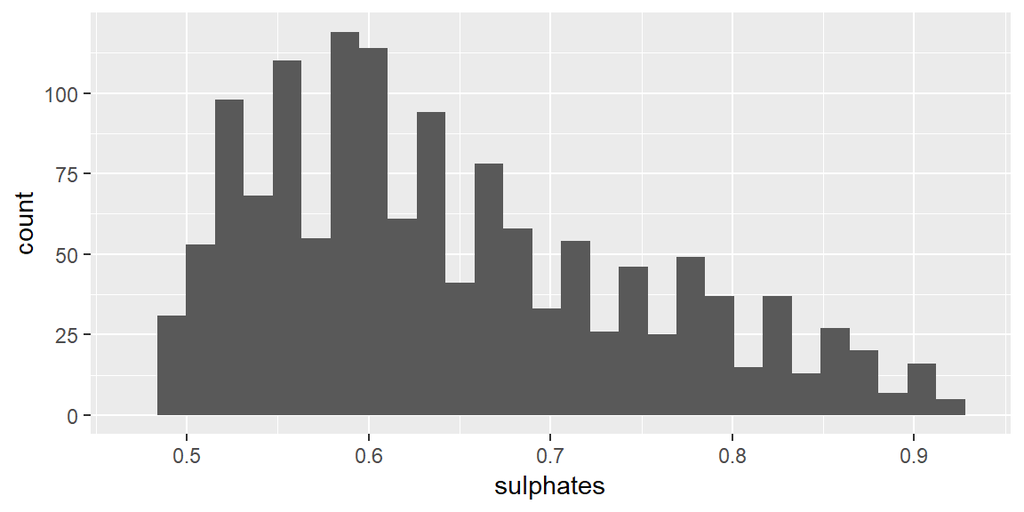

```
##    Min. 1st Qu.  Median    Mean 3rd Qu.    Max.
##  0.3300  0.5500  0.6200  0.6581  0.7300  2.0000
```

```
##
## FALSE  TRUE
##  1591     8
```

The minimum of sulphates is 0.33 and the maximum of sulphates is 2.000,but most sulphates are between 0.55 and 0.73. In particular, most are below 1.5. And There are some outliers.

[output not shown]

# Bivariate Analysis

Let’s plot the correlation of all varianles against each other.

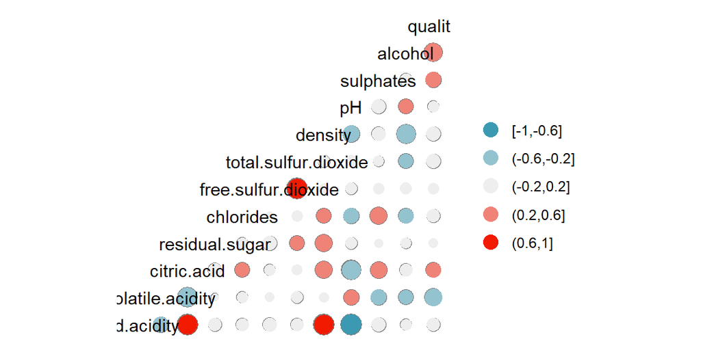

Create boxplots of these variables vs. quality can see how they affect the quality of the red wine.

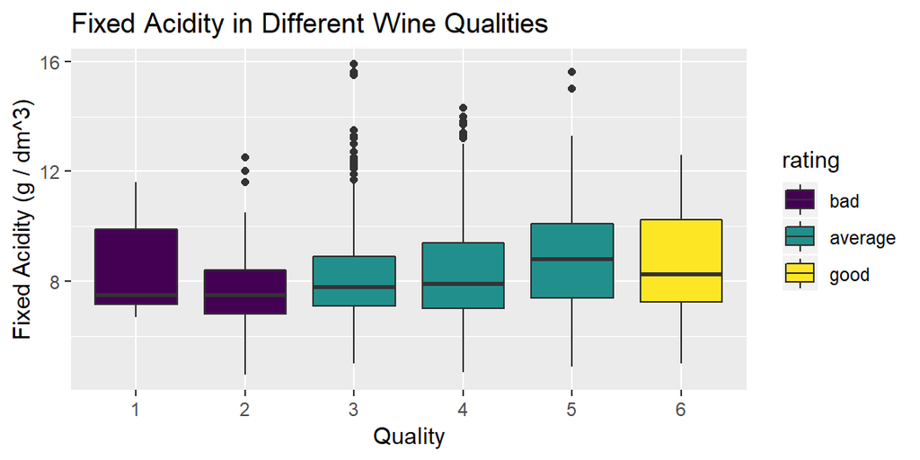

It seems like that higher quality red wine has higher fixed.acidity, but it’s not obvious.

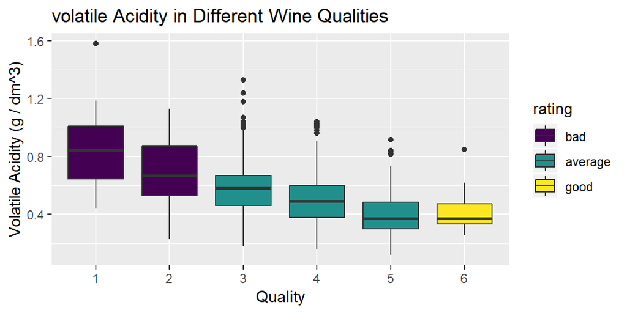

It’s clear that higher quality red wine has lower volatile.acidity.

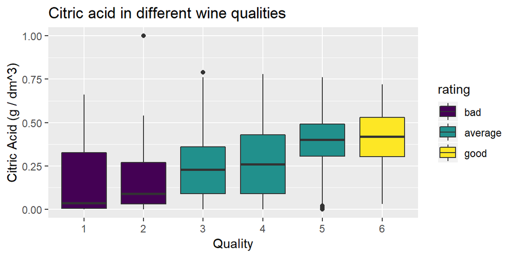

It’s clear that higher quality red wine has higher citric.acid.

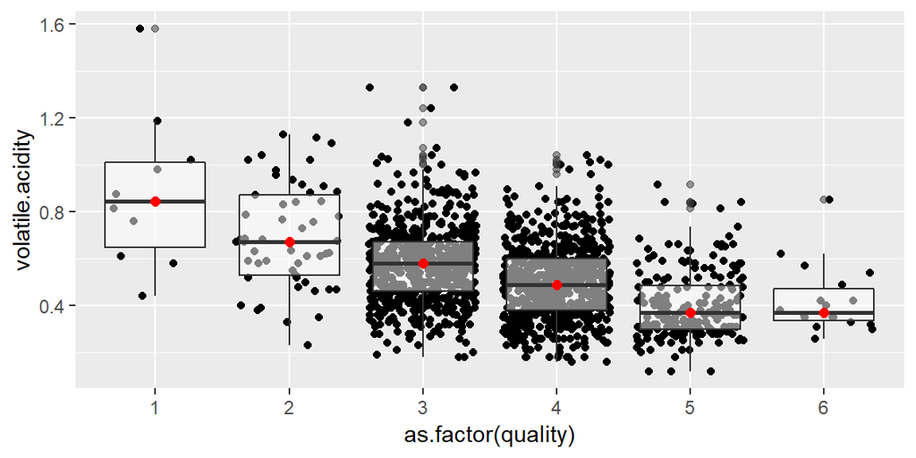

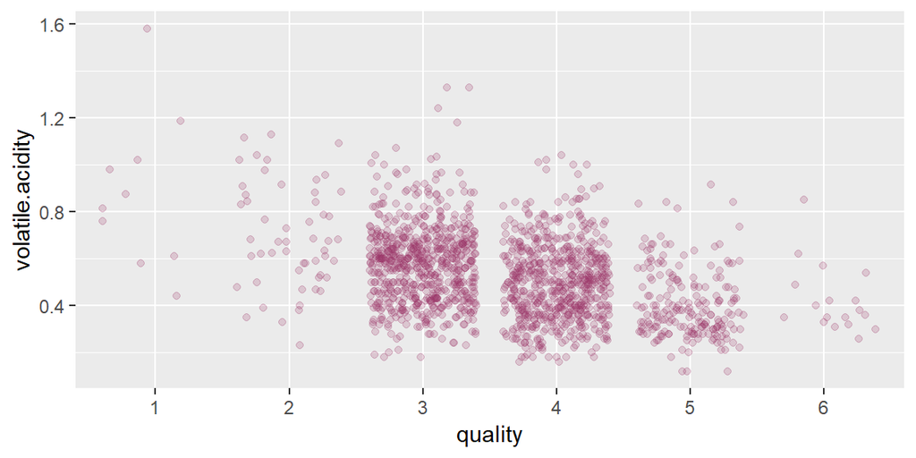

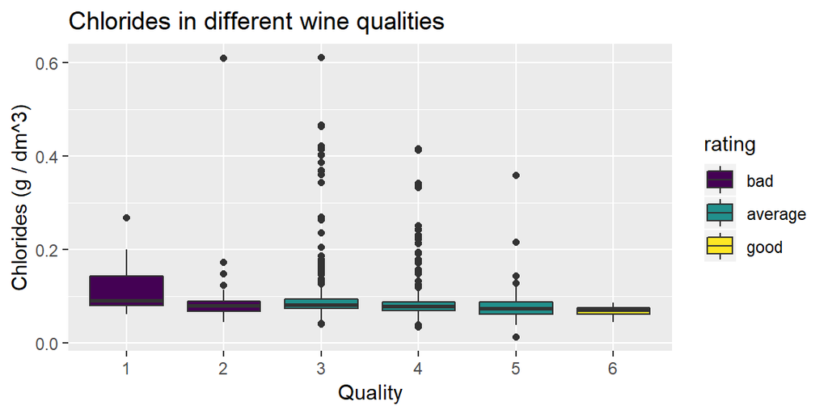

It seems like that higher quality red wine has lower chlorides.

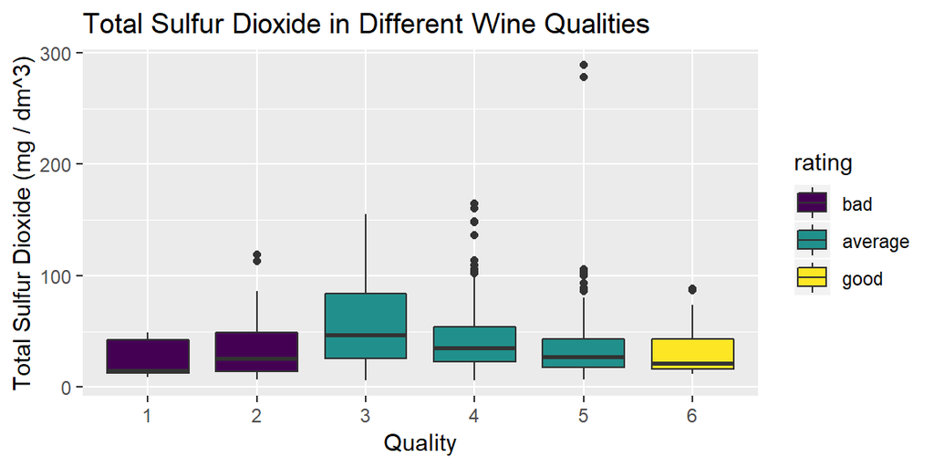

Cannot see specific relationship between total.sulfur.dioxide and quality.

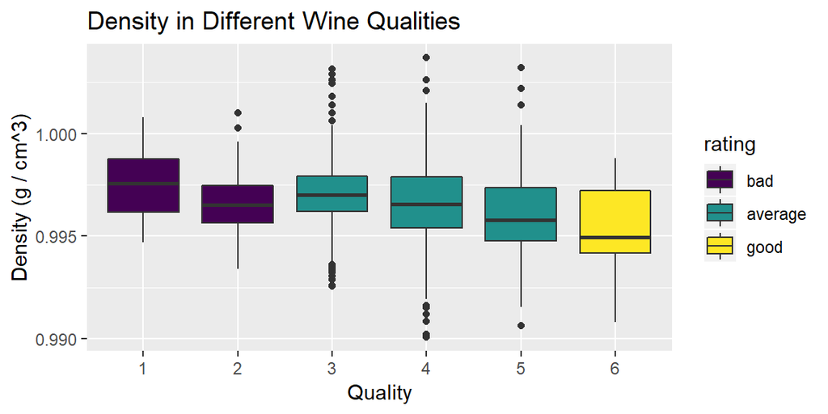

It shows that higher quality red wine has lower density.

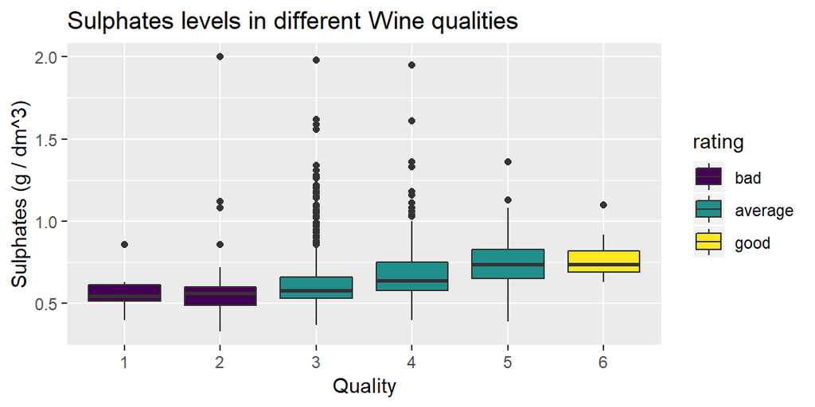

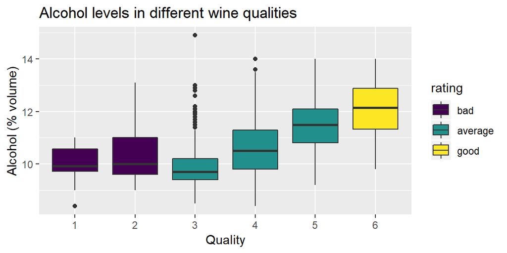

After explored all boxplots, there are no obvious relayionship between total.sulfur.dioxide and quality and I found that a good wine seems has the following characteristic:

- higer fixed.acidity, citric.acid, sulphates, and alcohol
- lower volatile.acidity, chlorides and density It shows that higher quality red wine has higher alcohols.